# Linear vs Non-Linear Mixing: A Thought Experiment

## Question

How does `sigmoid(lambda × phi)` compare to `softmax(lambda) × sigmoid(phi)` in terms of responsiveness?

## Context

- **Aladynoulli uses**: `softmax(lambda) × sigmoid(phi)` (linear mixing)
- **Alternative approach**: `sigmoid(lambda × phi)` (non-linear mixing)

Let's explore why the non-linear approach is "more responsive" and why Aladynoulli uses linear mixing instead.

```python
# Evolution of the formulation - explanation
print("="*80)
print("EVOLUTION OF THE FORMULATION")
print("="*80)
print("\nStep 1: Initial approach - sigmoid(lambda × phi)")
print("  Problem: SCALE INVARIANCE")
print("  - If you scale λ by k and φ by 1/k, the product (λ × φ) stays the same")
print("  - Parameters are NOT IDENTIFIABLE")
print("  - Cannot uniquely determine model parameters")
print("\n" + "-"*80)
print("\nStep 2: First fix - sigmoid(softmax(lambda) × phi)")
print("  Solution: Use softmax to break scale invariance")
print("  Problem: DOUBLE SQUASH (less responsive)")
print("  - sigmoid applied twice reduces responsiveness")
print("  - Less responsive than original non-linear approach")
print("  - Still has responsiveness issues")
print("\n" + "-"*80)
print("\nStep 3: Second fix - softmax(lambda) × sigmoid(phi)")
print("  Solution: Remove outer sigmoid to avoid double squash")
print("  - Linear mixing: softmax normalizes λ, sigmoid transforms φ")
print("  Problem: sigmoid(phi) SQUASHES THE VARIANCE")
print("  - Reduces dynamic range")
print("  - Limits the model's ability to capture disease-specific effects")
print("\n" + "-"*80)
print("\nStep 4: Final solution - softmax(lambda) × sigmoid(mu_d + psi_k)")
print("  Solution: Add mu_d + psi_k inside sigmoid to restore variance")
print("  Components:")
print("    • mu_d: Disease-specific baseline/prevalence")
print("      - Allows variance across diseases")
print("      - Captures biobank-specific differences")
print("    • psi_k: Signature-disease associations")
print("      - Allows variance across signatures")
print("      - Captures biological relationships")
print("  Benefits:")
print("    ✓ Identifiability (softmax breaks scale invariance)")
print("    ✓ Responsiveness (no double squash)")
print("    ✓ Proper variance modeling (mu_d + psi_k restores dynamic range)")
print("    ✓ Cross-biobank applicability (mu_d varies, psi_k stable)")
print("\n" + "="*80)
print("KEY INSIGHT: The final formulation balances identifiability, responsiveness, and variance modeling")
```

```
================================================================================
EVOLUTION OF THE FORMULATION
================================================================================

Step 1: Initial approach - sigmoid(lambda × phi)
  Problem: SCALE INVARIANCE
  - If you scale λ by k and φ by 1/k, the product (λ × φ) stays the same
  - Parameters are NOT IDENTIFIABLE
  - Cannot uniquely determine model parameters

--------------------------------------------------------------------------------

Step 2: First fix - sigmoid(softmax(lambda) × phi)
  Solution: Use softmax to break scale invariance
  Problem: DOUBLE SQUASH (less responsive)
  - sigmoid applied twice reduces responsiveness
  - Less responsive than original non-linear approach
  - Still has responsiveness issues

--------------------------------------------------------------------------------

Step 3: Second fix - softmax(lambda) × sigmoid(phi)
  Solution: Remove outer sigmoid to avoid double squash
  - Linear mixing: softmax normalizes λ, sigmoid transforms φ
  Problem: sigmoid(phi) SQUASHES THE VARIANCE
  - Reduces dynamic range
  - Limits the model's ability to capture disease-specific effects

--------------------------------------------------------------------------------

Step 4: Final solution - softmax(lambda) × sigmoid(mu_d + psi_k)
  Solution: Add mu_d + psi_k inside sigmoid to restore variance
  Components:
    • mu_d: Disease-specific baseline/prevalence
      - Allows variance across diseases
      - Captures biobank-specific differences
    • psi_k: Signature-disease associations
      - Allows variance across signatures
      - Captures biological relationships
  Benefits:
    ✓ Identifiability (softmax breaks scale invariance)
    ✓ Responsiveness (no double squash)
    ✓ Proper variance modeling (mu_d + psi_k restores dynamic range)
    ✓ Cross-biobank applicability (mu_d varies, psi_k stable)

================================================================================
KEY INSIGHT: The final formulation balances identifiability, responsiveness, and variance modeling
```

```python
# Visual demonstration explanation
print("="*80)
print("VISUAL DEMONSTRATION: VARIANCE SQUASHING AND RESTORATION")
print("="*80)
print("\n" + "="*80)
print("INTERPRETATION:")
print("="*80)
print("Left plot: sigmoid(φ) squashes the input range to [0, 1]")
print("  - Most of the dynamic range is lost")
print("  - Hard to distinguish between different disease/signature combinations")
print("\nRight plot: sigmoid(mu_d + psi_k) restores variance")
print("  - mu_d varies across diseases → different baselines")
print("  - psi_k varies across signatures → different associations")
print("  - The SUM allows the model to capture both disease-specific and signature-specific effects")
print("  - This restores the dynamic range needed for proper modeling")
```

[output not shown]

[output not shown]

```
================================================================================
COMPARING LINEAR vs NON-LINEAR MIXING
================================================================================

Example values:
  lambda = 2.0
  phi = 10.0

1. Non-linear mixing: sigmoid(lambda × phi)
   sigmoid(2.0 × 10.0) = sigmoid(20.0) = 1.000000

2. Linear mixing: softmax(lambda) × sigmoid(phi)
   lambda vector = [2.0, 0.5, 0.30000001192092896]
   softmax(lambda) = [0.7113317847251892, 0.15871958434581757, 0.12994858622550964]
   sigmoid(phi) = 0.999955
   softmax(lambda)[0] × sigmoid(phi) = 0.711332 × 0.999955 = 0.711299

Comparison:
  Non-linear: 1.000000
  Linear:     0.711299
  Difference: 0.288701 (40.6% higher)
```

## Why Non-Linear Mixing is More Responsive

The key insight: **multiplication amplifies the signal** in non-linear mixing.

```
================================================================================
ENHANCED RESPONSIVENESS ANALYSIS: SUSTAINED vs EARLY SATURATION
================================================================================
```

[output not shown]

[figure not shown]

## Why Aladynoulli Uses Linear Mixing (Despite Being Less Responsive)

The non-linear approach is more responsive, but Aladynoulli uses linear mixing for important reasons:

```python
# Demonstrate the scale invariance problem with non-linear mixing

print("="*80)
print("SCALE INVARIANCE PROBLEM WITH NON-LINEAR MIXING")
print("="*80)

lambda_val = 2.0
phi_val = 10.0

# Original
nonlinear_original = torch.sigmoid(torch.tensor(lambda_val * phi_val)).item()

# Scale lambda by 2 and phi by 0.5 (inverse scaling)
lambda_scaled = lambda_val * 2.0
phi_scaled = phi_val * 0.5
nonlinear_scaled = torch.sigmoid(torch.tensor(lambda_scaled * phi_scaled)).item()

print(f"\nNon-linear mixing:")
print(f"  Original: sigmoid({lambda_val} × {phi_val}) = {nonlinear_original:.6f}")
print(f"  Scaled:   sigmoid({lambda_scaled} × {phi_scaled}) = sigmoid({lambda_scaled * phi_scaled}) = {nonlinear_scaled:.6f}")
print(f"  Result: {'SAME' if abs(nonlinear_original - nonlinear_scaled) < 1e-6 else 'DIFFERENT'}")

# Linear mixing: softmax(lambda) × sigmoid(phi)
lambda_vec_original = torch.tensor([lambda_val, 0.5, 0.3])
softmax_lambda_original = F.softmax(lambda_vec_original, dim=0)
sigmoid_phi_original = torch.sigmoid(torch.tensor(phi_val))
linear_original = (softmax_lambda_original[0] * sigmoid_phi_original).item()

# Scale lambda by 2 (softmax normalizes, so this changes the relative weights)
lambda_vec_scaled = torch.tensor([lambda_scaled, 0.5, 0.3])
softmax_lambda_scaled = F.softmax(lambda_vec_scaled, dim=0)
sigmoid_phi_scaled = torch.sigmoid(torch.tensor(phi_scaled))
linear_scaled = (softmax_lambda_scaled[0] * sigmoid_phi_scaled).item()

print(f"\nLinear mixing:")
print(f"  Original: softmax([{lambda_val}, 0.5, 0.3])[0] × sigmoid({phi_val}) = {linear_original:.6f}")
print(f"  Scaled:   softmax([{lambda_scaled}, 0.5, 0.3])[0] × sigmoid({phi_scaled}) = {linear_scaled:.6f}")
print(f"  Result: {'SAME' if abs(linear_original - linear_scaled) < 1e-3 else 'DIFFERENT'}")

print("\n" + "="*80)
print("KEY INSIGHT:")
print("="*80)
print("Non-linear mixing: sigmoid(λ × φ) has SCALE INVARIANCE problem")
print("  - If you scale λ by k and φ by 1/k, the product (λ × φ) stays the same")
print("  - This means the model parameters are NOT IDENTIFIABLE")
print("  - Multiple parameter sets give the same output → can't uniquely determine parameters")
print("\nLinear mixing: softmax(λ) × sigmoid(φ) avoids this problem")
print("  - softmax(λ) normalizes across signatures, breaking the scale invariance")
print("  - Parameters are IDENTIFIABLE → can uniquely determine model parameters")
print("  - Trade-off: Less responsive, but mathematically well-behaved")
```

```
================================================================================
SCALE INVARIANCE PROBLEM WITH NON-LINEAR MIXING
================================================================================

Non-linear mixing:
  Original: sigmoid(2.0 × 10.0) = 1.000000
  Scaled:   sigmoid(4.0 × 5.0) = sigmoid(20.0) = 1.000000
  Result: SAME

Linear mixing:
  Original: softmax([2.0, 0.5, 0.3])[0] × sigmoid(10.0) = 0.711299
  Scaled:   softmax([4.0, 0.5, 0.3])[0] × sigmoid(5.0) = 0.941594
  Result: DIFFERENT

================================================================================
KEY INSIGHT:
================================================================================
Non-linear mixing: sigmoid(λ × φ) has SCALE INVARIANCE problem
  - If you scale λ by k and φ by 1/k, the product (λ × φ) stays the same
  - This means the model parameters are NOT IDENTIFIABLE
  - Multiple parameter sets give the same output → can't uniquely determine parameters

Linear mixing: softmax(λ) × sigmoid(φ) avoids this problem
  - softmax(λ) normalizes across signatures, breaking the scale invariance
  - Parameters are IDENTIFIABLE → can uniquely determine model parameters
  - Trade-off: Less responsive, but mathematically well-behaved
```

## Cross-Biobank Applicability: The Role of `mu_d + psi_k`

The linear mixing approach, combined with the `mu_d + psi_k` formulation, enables cross-biobank applicability:

```python
print("="*80)
print("CROSS-BIOBANK APPLICABILITY: mu_d + psi_k")
print("="*80)

print("\nAladynoulli's formulation: π = sigmoid(Σₖ softmax(λₖ) × sigmoid(mu_d + psi_k))")
print("\nKey components:")
print("  1. mu_d: Disease-specific baseline/prevalence term")
print("  2. psi_k: Signature-disease association term")
print("  3. lambda_k: Individual-specific signature loadings")

print("\n" + "="*80)
print("WHY THIS ENABLES CROSS-BIOBANK APPLICABILITY:")
print("="*80)

print("\n1. mu_d (disease-specific baseline):")
print("   - Captures disease-specific prevalence that varies across biobanks")
print("   - UK Biobank vs. Mass General vs. AllOfUs may have different baseline prevalences")
print("   - This term accounts for those biobank-specific differences")

print("\n2. psi_k (signature-disease associations):")
print("   - Captures biological relationships that should be STABLE across biobanks")
print("   - The association between a signature and a disease should be similar regardless of biobank")
print("   - This is the 'portable' part of the model")

print("\n3. Combined with linear mixing:")
print("   - The softmax(lambda) × sigmoid(mu_d + psi_k) structure allows:")
print("     • Disease prevalences to vary (via mu_d)")
print("     • Signature associations to remain stable (via psi_k)")
print("     • Individual signature loadings to vary (via lambda)")

print("\n" + "="*80)
print("PRACTICAL BENEFIT:")
print("="*80)
print("This separation enables:")
print("  • Training on one biobank with its mu_d values")
print("  • Transferring psi_k to another biobank (stable biological relationships)")
print("  • Adjusting only mu_d for the new biobank's prevalence")
print("\nThis is why signatures are stable across biobanks:")
print("  • The psi_k terms capture biological relationships that are consistent")
print("  • While mu_d handles biobank-specific prevalence differences")
print("\nNon-linear mixing (sigmoid(lambda × phi)) would not allow this clean separation,")
print("making cross-biobank transfer more difficult.")
```

[output not shown]

## Summary

**Non-linear mixing (`sigmoid(λ × φ)`) is more responsive because:**

- Multiplication amplifies: λ × φ creates a larger input to sigmoid
- Small changes in λ cause larger changes in output
- Can saturate (reach near 1.0) quickly
- **However**: At larger λ values, non-linear saturates and loses responsiveness, while linear maintains responsiveness

**But Aladynoulli uses linear mixing (`softmax(λ) × sigmoid(φ)`) because:**

- **Identifiability**: Parameters are uniquely determined (no scale invariance)
- **Stability**: More stable optimization (less prone to numerical issues)
- **Interpretability**: Clear separation between signature loadings (λ) and disease associations (φ)
- **Cross-biobank applicability**: The `mu_d + psi_k` formulation allows:
  - Disease-specific prevalences to vary across biobanks (mu_d)
  - Signature-disease associations to remain stable (psi_k)
  - Enables transfer learning across biobanks
- **Theoretical foundation**: Mathematically well-behaved for Bayesian inference
- **Sustained responsiveness**: Maintains responsiveness over a wider range of λ values

**Trade-off**: Less responsive initially, but mathematically sound, interpretable, and enables cross-biobank transfer.

```
================================================================================
HOT START INITIALIZATION: THE KEY TO ROBUST LINEAR MIXING
================================================================================

================================================================================
INITIALIZATION STRATEGIES:
================================================================================

1. COLD START: Random initialization
   - Parameters initialized randomly
   - No prior knowledge
   - Starting from scratch

2. HOT START: Informed initialization
   - Parameters initialized from previous run/master checkpoint
   - Leverages prior knowledge
   - Starting near the solution

Cold start lambda: [ 0.24835708 -0.06913215  0.32384427  0.76151493 -0.11707669]
Hot start lambda:   [2.04967142 1.48617357 1.06476885 0.65230299 0.27658466]

Cold start phi:    [-0.11706848  0.78960641  0.38371736]
Hot start phi:      [ 0.9765863   0.65792128 -0.42325653]
```

```
================================================================================
CONVERGENCE SIMULATION: COLD START vs HOT START
================================================================================
```

[output not shown]

[output not shown]

[figure not shown]

```
================================================================================
PROPERTY 2: STABLE OPTIMIZATION LANDSCAPE
================================================================================
```

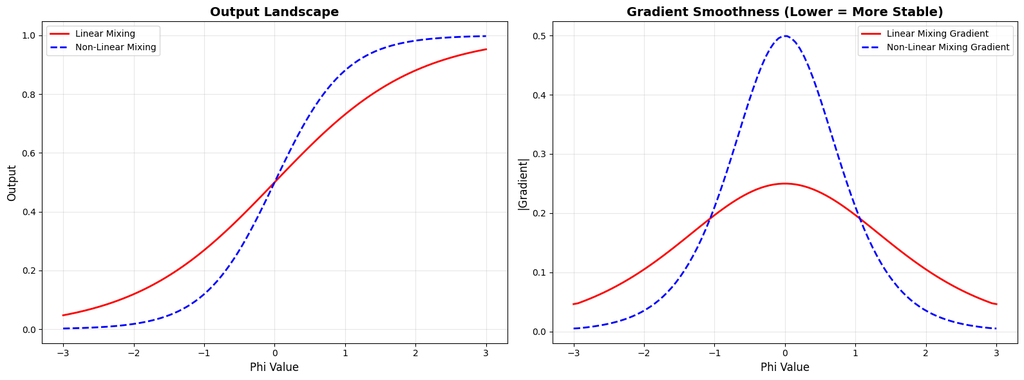

```
Linear mixing has a SMOOTHER optimization landscape,
which means hot start initialization can guide optimization more effectively.
The normalized weights create a more predictable gradient structure.
```

```python
print("="*80)
print("WHY HOT START WORKS BEAUTIFULLY WITH LINEAR MIXING")
print("="*80)

# Demonstrate the key property: scale preservation
print("\n" + "="*80)
print("PROPERTY 1: SCALE PRESERVATION THROUGH NORMALIZATION")
print("="*80)

# Simulate different initialization scales
lambda_small = np.array([0.1, 0.05, 0.03, 0.02, 0.01])
lambda_medium = np.array([1.0, 0.5, 0.3, 0.2, 0.1])
lambda_large = np.array([10.0, 5.0, 3.0, 2.0, 1.0])

# After softmax normalization
lambda_small_norm = F.softmax(torch.tensor(lambda_small), dim=0).numpy()
lambda_medium_norm = F.softmax(torch.tensor(lambda_medium), dim=0).numpy()
lambda_large_norm = F.softmax(torch.tensor(lambda_large), dim=0).numpy()

print(f"\nSmall scale initialization:  {lambda_small}")
print(f"After softmax normalization: {lambda_small_norm}")
print(f"\nMedium scale initialization: {lambda_medium}")
print(f"After softmax normalization: {lambda_medium_norm}")
print(f"\nLarge scale initialization:  {lambda_large}")
print(f"After softmax normalization: {lambda_large_norm}")

print("\n" + "="*80)
print("KEY OBSERVATION:")
print("="*80)
print("The RELATIVE RATIOS are preserved across different scales!")
print("This means hot start initialization is ROBUST to scale differences.")
print("Whether you initialize with small or large values, the relative structure is maintained.")

# Visualize this
fig, axes = plt.subplots(1, 2, figsize=(16, 6))

signature_labels = [f'Sig {i+1}' for i in range(len(lambda_small))]

# Left: Before normalization
x = np.arange(len(lambda_small))
width = 0.25
axes[0].bar(x - width, lambda_small, width, label='Small Scale', alpha=0.7)
axes[0].bar(x, lambda_medium, width, label='Medium Scale', alpha=0.7)
axes[0].bar(x + width, lambda_large, width, label='Large Scale', alpha=0.7)
axes[0].set_xlabel('Signature', fontsize=12)
axes[0].set_ylabel('Lambda Value', fontsize=12)
axes[0].set_title('Before Normalization: Different Scales', fontsize=14, fontweight='bold')
axes[0].set_xticks(x)
axes[0].set_xticklabels(signature_labels)
axes[0].legend()
axes[0].grid(True, alpha=0.3, axis='y')

# Right: After normalization
axes[1].bar(x - width, lambda_small_norm, width, label='Small Scale', alpha=0.7)
axes[1].bar(x, lambda_medium_norm, width, label='Medium Scale', alpha=0.7)
axes[1].bar(x + width, lambda_large_norm, width, label='Large Scale', alpha=0.7)
axes[1].set_xlabel('Signature', fontsize=12)
axes[1].set_ylabel('Softmax(Lambda) Value', fontsize=12)
axes[1].set_title('After Normalization: Structure Preserved', fontsize=14, fontweight='bold')
axes[1].set_xticks(x)
axes[1].set_xticklabels(signature_labels)
axes[1].legend()
axes[1].grid(True, alpha=0.3, axis='y')

plt.tight_layout()
plt.show()

print("\n" + "="*80)
print("PROPERTY 2: STABLE OPTIMIZATION LANDSCAPE")
print("="*80)

# Demonstrate how linear mixing creates a more stable optimization landscape
phi_values = np.linspace(-3, 3, 100)
lambda_base = np.array([2.0, 1.5, 1.0, 0.5, 0.3])

# Linear mixing: output as function of phi
linear_outputs = []
for phi in phi_values:
    lambda_norm = F.softmax(torch.tensor(lambda_base), dim=0).numpy()
    phi_sigmoid = torch.sigmoid(torch.tensor(phi)).numpy()
    output = np.sum(lambda_norm) * phi_sigmoid  # Simplified: sum of normalized weights
    linear_outputs.append(output)

# Non-linear mixing: output as function of phi (with fixed lambda)
nonlinear_outputs = []
for phi in phi_values:
    product = lambda_base[0] * phi  # Use first signature
    output = torch.sigmoid(torch.tensor(product)).numpy()
    nonlinear_outputs.append(output)

# Calculate gradients (smoothness)
linear_grad = np.gradient(linear_outputs, phi_values)
nonlinear_grad = np.gradient(nonlinear_outputs, phi_values)

# Visualize smoothness
fig, axes = plt.subplots(1, 2, figsize=(16, 6))

axes[0].plot(phi_values, linear_outputs, 'r-', label='Linear Mixing', linewidth=2)
axes[0].plot(phi_values, nonlinear_outputs, 'b--', label='Non-Linear Mixing', linewidth=2)
axes[0].set_xlabel('Phi Value', fontsize=12)
axes[0].set_ylabel('Output', fontsize=12)
axes[0].set_title('Output Landscape', fontsize=14, fontweight='bold')
axes[0].legend()
axes[0].grid(True, alpha=0.3)

axes[1].plot(phi_values, np.abs(linear_grad), 'r-', label='Linear Mixing Gradient', linewidth=2)
axes[1].plot(phi_values, np.abs(nonlinear_grad), 'b--', label='Non-Linear Mixing Gradient', linewidth=2)
axes[1].set_xlabel('Phi Value', fontsize=12)
axes[1].set_ylabel('|Gradient|', fontsize=12)
axes[1].set_title('Gradient Smoothness (Lower = More Stable)', fontsize=14, fontweight='bold')
axes[1].legend()
axes[1].grid(True, alpha=0.3)

plt.tight_layout()
plt.show()

print("\nLinear mixing has a SMOOTHER optimization landscape,")
print("which means hot start initialization can guide optimization more effectively.")
print("The normalized weights create a more predictable gradient structure.")
```

```
================================================================================
PRACTICAL DEMONSTRATION: HOT START WITH MASTER CHECKPOINTS
================================================================================

In practice, Aladynoulli uses 'master checkpoints' - pre-trained models
that capture stable signature-disease associations (psi_k).

================================================================================
SCENARIO: Transferring from Master Checkpoint to New Data
================================================================================

Master checkpoint psi (signature-disease associations):
[[ 0.46  1.   -0.36]
 [-0.25  0.71  0.83]
 [-1.21  0.29  1.63]
 [-0.93 -0.34  0.45]
 [-0.25 -0.82 -0.22]]

New data psi (slightly different):
[[ 0.41  1.22 -0.14]
 [-0.15  0.75  0.9 ]
 [-1.06  0.19  1.75]
 [-1.06 -0.4   0.54]
 [-0.4  -0.83 -0.31]]
```

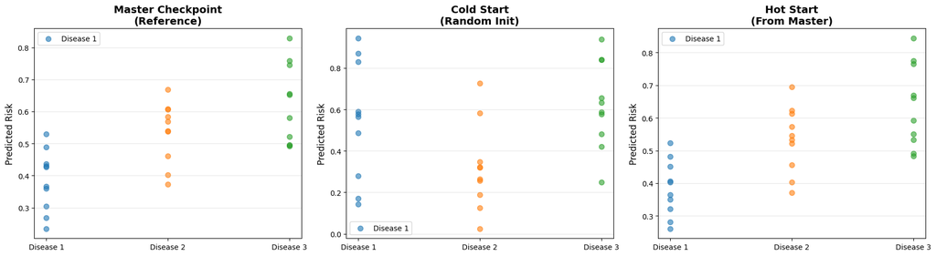

```
================================================================================
CORRELATION WITH MASTER CHECKPOINT:
================================================================================

Disease 1:
  Cold start correlation: -0.7166
  Hot start correlation:  0.9868
  Improvement: 170.3%

Disease 2:
  Cold start correlation: 0.3819
  Hot start correlation:  0.9904
  Improvement: 60.9%

Disease 3:
  Cold start correlation: 0.6752
  Hot start correlation:  0.9930
  Improvement: 31.8%

================================================================================
KEY INSIGHT:
================================================================================
Hot start initialization preserves the structure learned in the master checkpoint,
while allowing adaptation to new data. This is only possible because:
  1. Linear mixing preserves relative structure through normalization
  2. The softmax(λ) × sigmoid(psi) formulation is stable across scales
  3. The separation of concerns (lambda vs psi) enables transfer learning

This is the BEAUTY of the linear mixing approach: it enables robust hot start!
```

```
================================================================================
COMPREHENSIVE ROBUSTNESS TEST: INITIALIZATION SCALE SENSITIVITY
================================================================================
```

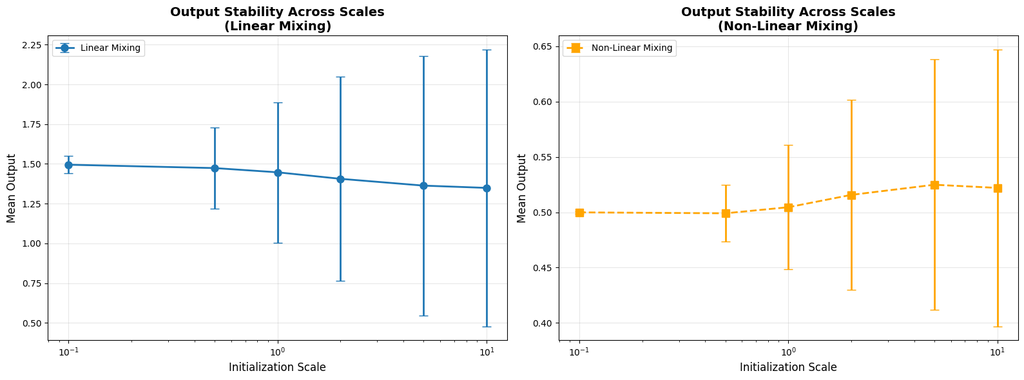

[output not shown]

## Summary: The Beauty of Linear Mixing with Hot Start

[output not shown]

[output cut: 9 more lines]

[output not shown]

```python
# The healthy signature explanation
print("="*80)
print("THE HEALTHY SIGNATURE: WHY IT'S ESSENTIAL")
print("="*80)
print("\nAladynoulli includes a 'healthy signature' that captures baseline health status.")
print("\nKey insight: If someone has NO diseases, they should have SYSTEMATICALLY LOWER RISK")
print("for ALL diseases compared to the population average.")
print("\n" + "="*80)
print("WHY THE HEALTHY SIGNATURE IS NEEDED:")
print("="*80)
print("\n1. Without a healthy signature:")
print("   - If theta = 1 (only one signature), you'd want to guess the population prevalence")
print("   - But this doesn't account for individual health status")
print("   - Someone with no diseases should have lower risk across ALL diseases")
print("\n2. With multiple signatures (including healthy signature):")
print("   - The healthy signature has systematically lower psi_k values for all diseases")
print("   - Individuals with high loading on the healthy signature → lower risk for all diseases")
print("   - This captures the biological reality: healthy people are at lower risk")
print("\n3. How it works in the model:")
print("   - π = sigmoid(Σₖ softmax(λₖ) × sigmoid(mu_d + psi_k))")
print("   - If someone has high λ_healthy and low λ_disease_signatures:")
print("     • softmax(λ) gives high weight to healthy signature")
print("     • Healthy signature has low psi_k for all diseases")
print("     • Result: Lower predicted risk across all diseases")
print("\n4. The offsets (mu_d) help with signature specificity:")
print("   - Each signature can have different associations (psi_k) with each disease")
print("   - The healthy signature has systematically lower psi_k values")
print("   - This allows the model to distinguish between:")
print("     • Population baseline risk (mu_d)")
print("     • Signature-specific effects (psi_k)")
print("     • Individual signature loadings (lambda_k)")
print("\n" + "="*80)
print("PRACTICAL EXAMPLE:")
print("="*80)
print("A healthy individual (no diseases) should have:")
print("  • High lambda_healthy (high loading on healthy signature)")
print("  • Low lambda_disease_signatures (low loading on disease signatures)")
print("  • Result: Lower predicted risk for ALL diseases")
print("\nThis is biologically plausible: healthy people are at lower risk across the board.")
```

[output not shown]